# ordinal_modelling

Nicolás Sánchez-Fuenzalida

2024-02-22

```r
# Packages
if (!require('pacman', quietly = TRUE)) install.packages('pacman'); library('pacman', quietly = TRUE)
p_load(here, readr, BayesFactor, magrittr, dplyr, purrr, stringr, ggplot2)
source(here('scripts/funcs.R'))
```

```r
# to reproduce results
set.seed(seed = 12345)
```

### Data

```r
# Read data
if (exp_data == 'both') {

  # Read decision data
  dec_dat <-
    bind_rows(
      read_csv(here('data/processed/decision_predicted_curve_concurrent.csv'), col_types = cols()),
      read_csv(here('data/processed/decision_predicted_curve_delayed.csv'), col_types = cols())
    )

  # Read confidence data
  conf_dat <-
    bind_rows(
      read_csv(here('data/processed/confidence_predicted_curve_concurrent.csv'), col_types = cols()),
      read_csv(here('data/processed/confidence_predicted_curve_delayed.csv'), col_types = cols())
    )

} else if (exp_data == 'exp1') {

  # Read decision data
  dec_dat <-
    bind_rows(
      read_csv(here('data/processed/decision_predicted_curve_concurrent.csv'), col_types = cols())
    )

  # Read confidence data
  conf_dat <-
    bind_rows(
      read_csv(here('data/processed/confidence_predicted_curve_concurrent.csv'), col_types = cols())
    )

} else if (exp_data == 'exp2') {

  # Read decision data
  dec_dat <-
    bind_rows(
      read_csv(here('data/processed/decision_predicted_curve_delayed.csv'), col_types = cols())
    )

  # Read confidence data
  conf_dat <-
    bind_rows(
      read_csv(here('data/processed/confidence_predicted_curve_delayed.csv'), col_types = cols())
    )
}
```

### Get PSE and PMU

```r
# Get PSE
dec_dat <-
  dec_dat %>%
  get_pse() %>%
  ungroup() %>%
  select(-data)

# Get PMU
conf_dat <-
  conf_dat %>%
  get_lowest_conf() %>%
  ungroup() %>%
  select(-value)

# Remove participants without point to test -------------------------------

# remove participants with bad fits
bad_fits <- read_csv(here('data/processed/bad_fits.csv'))
# filter out people
dec_dat <- dec_dat %>% anti_join(bad_fits %>% select(-c(data, type)))
conf_dat <- conf_dat %>% anti_join(bad_fits %>% select(-c(data, type)))
# Calculate differences in decision PSE
dec_dat <- dec_dat %>%
  pivot_wider(names_from = bias_direction, values_from = target_length) %>%
  mutate(pse = short - long) %>%
  select(-c(short, long))

# Calculate differences in confidence PMU
conf_dat <- conf_dat %>%
  pivot_wider(names_from = bias_direction, values_from = target_length) %>%
  mutate(pmu = short - long) %>%
  select(-c(short, long))
```

```r
# Combine all data
dat <- full_join(dec_dat, conf_dat)
```

```r
# Put data in long format
dat <- dat %>%
  pivot_longer(names_to = 'task', values_to = 'value', cols = c(pse, pmu))

# Renumber participants. In both experiments participant numbers are counted from 0 so there will be overlapping in numbers.
dat <-
  dat %>%
  group_by(confidence_type, participant) %>%
  mutate(participant = sprintf('S%04d', (cur_group_id()))) %>%
  ungroup()

# Create condition code
dat <-
  dat %>%
  mutate(cond_code = paste0(substr(bias_source, 1, 2), substr(task, 1, 3)))

# Sort data. This is not necessary for the analysis, it just makes the contrast plots easier to read
dat <- dat %>%
  arrange(bias_source, task)

# Count subjects
dat %>%
  group_by(bias_source) %>%
  select(bias_source, participant) %>%
  distinct() %>%
  reframe(count = n())
```

```
## # A tibble: 3 × 2
##   bias_source count
##   <chr>       <int>
## 1 baserate       46
## 2 mullerlyer     27
## 3 payoff         35
```

```r
# Summarize estimation
dat %>%
  group_by(bias_source, task) %>%
  reframe(value=mean(value)) %>%
  pivot_wider(names_from = task, values_from = value) %>%
  mutate(delta = pmu - pse)
```

```
## # A tibble: 3 × 4
##   bias_source   pmu   pse  delta
##   <chr>       <dbl> <dbl>  <dbl>
## 1 baserate     7.33 14.5   -7.19
## 2 mullerlyer  12.3   7.78   4.55
## 3 payoff      10.7  21.4  -10.7
```

## Get functions to create contrasts

```r
source(here('scripts/ordinal_model_scripts/functions_ordinal_modeling_diff_dec_conf.R'))
```

```r
contrast_value_pse <- -.5
contrast_value_pmu <- .5
```

## Bayes sampling

### Settings

Same settings for all models.

```r
# Iteration N
no_iter <- 5000
filter_iter <- .1
# R scale (effect size)
r <- .707
```

## Contrast matrices

### Subject contrast

This chunk creates a contrast matrix to indicate to which subject each observation belongs.

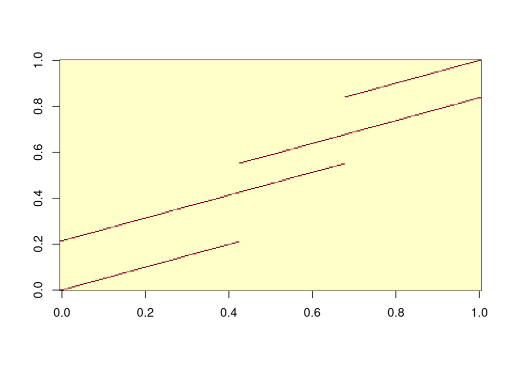

```r
# Run analysis including subject contrast?
include_id_contrast = TRUE

# Get id contrast matrix
id_contrast <- get_id_contrast(id_col = dat %>% select(participant) %>% rename(id=participant))

# Display matrix
image(t(id_contrast))
```

### Contrast A: decision & confidence are different in all conditions

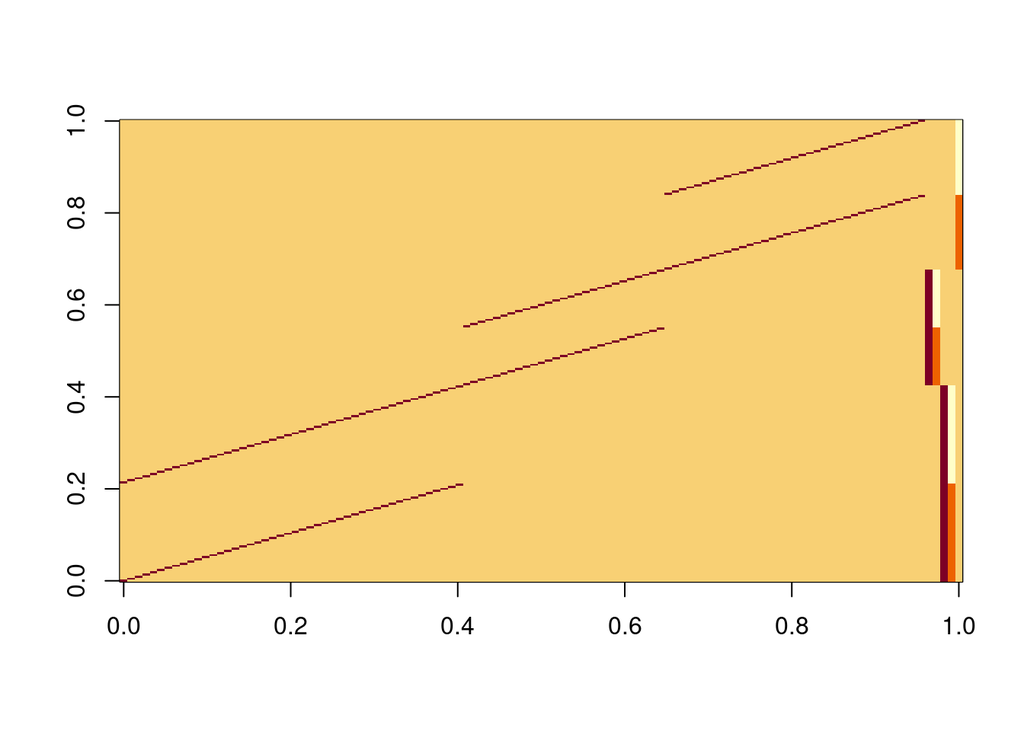

```r
# Get contrast
X_a <- get_contrast_A(dat, val_pse = contrast_value_pse, val_pmu = contrast_value_pmu)
# Full contrast image
image(t(X_a))
```

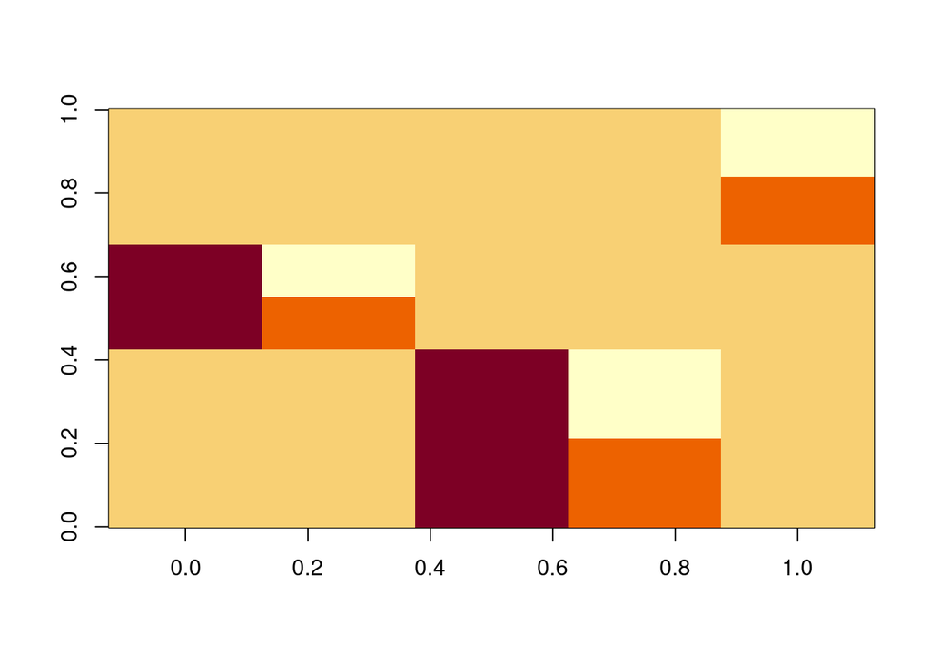

```r
# Only manipulation contrast
make_condition_contrast_image(X_a)
```

#### nWayAov

```r
# Get gMap
gMap <- get_gMap(X_a)
# Run nWayAOV
out <- get_bf_samp(y = dat$value, x = X_a, gMap = gMap, rscale = r,
                   no_iter = no_iter, filter_iter = filter_iter)
# Get simple BF
bf_out_a <- out[[1]]
# Get sampled data
samp_out_a <- out[[2]]
```

##### Check estimated values

```r
checkmeans_a <- with(dat, tapply(value, cond_code, mean))
pm.effest.a <- colMeans(samp_out_a)
```

Contrast A :

- mu: pay-off intercept
- beta 1: muller-lyer intercept
- beta 2: muller-lyer (pse-pmu)
- beta 3: base-rate intercept
- beta 4: base-rate (pse-pmu)
- beta 5: pay-off (pse-pmu)

```r
# get bias manipulation beta names
beta_names <- paste0('beta_', grep('x[0-9]{1}$', colnames(X_a)))

# Rename columns
sampled_means_a <-
  set_names(pm.effest.a[c('mu', beta_names)], c('mu', 'ml_int', 'ml_bd', 'br_int', 'br_bd', 'po_bd'))

# Compare means
checkmeans_a
```

```
##     bapmu     bapse     mupmu     mupse     papmu     papse
##  7.330435 14.517078 12.337037  7.783744 10.662857 21.367954
```

```r
c(
  'bapmu' = sampled_means_a['mu'] + sampled_means_a['br_int'] + contrast_value_pmu * sampled_means_a['br_bd'],
  'bapse' = sampled_means_a['mu'] + sampled_means_a['br_int'] + contrast_value_pse * sampled_means_a['br_bd'],

  'mupmu' = sampled_means_a['mu'] + sampled_means_a['ml_int'] + contrast_value_pmu * sampled_means_a['ml_bd'],
  'mupse' = sampled_means_a['mu'] + sampled_means_a['ml_int'] + contrast_value_pse * sampled_means_a['ml_bd'],

  'papmu' = sampled_means_a['mu'] + contrast_value_pmu * sampled_means_a['po_bd'],
  'papse' = sampled_means_a['mu'] + contrast_value_pse * sampled_means_a['po_bd']

)
```

```
##  bapmu.mu  bapse.mu  mupmu.mu  mupse.mu  papmu.mu  papse.mu
##  7.947106 14.513264 12.607962  8.760520 10.195465 20.102250
```

### Contrast E: decision & confidence are different in the Muller-Lyer condition, no difference in base rate and payoff

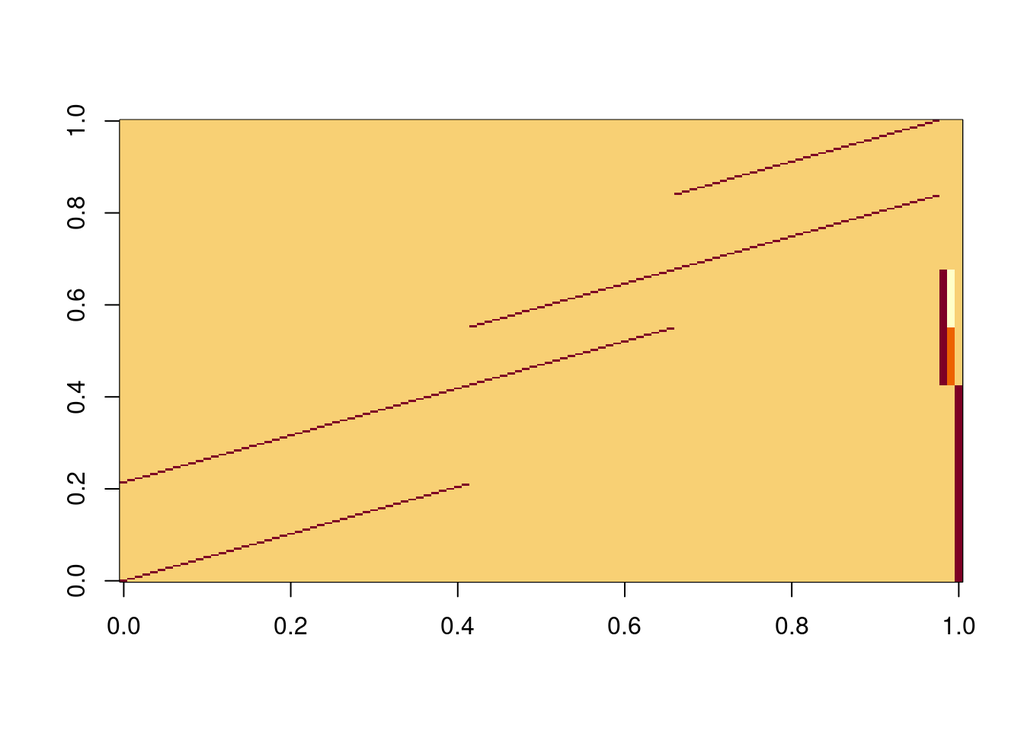

```r
# Get contrast
X_e <- get_contrast_E(dat, val_pse = contrast_value_pse, val_pmu = contrast_value_pmu)
# Full contrast image
image(t(X_e))
```

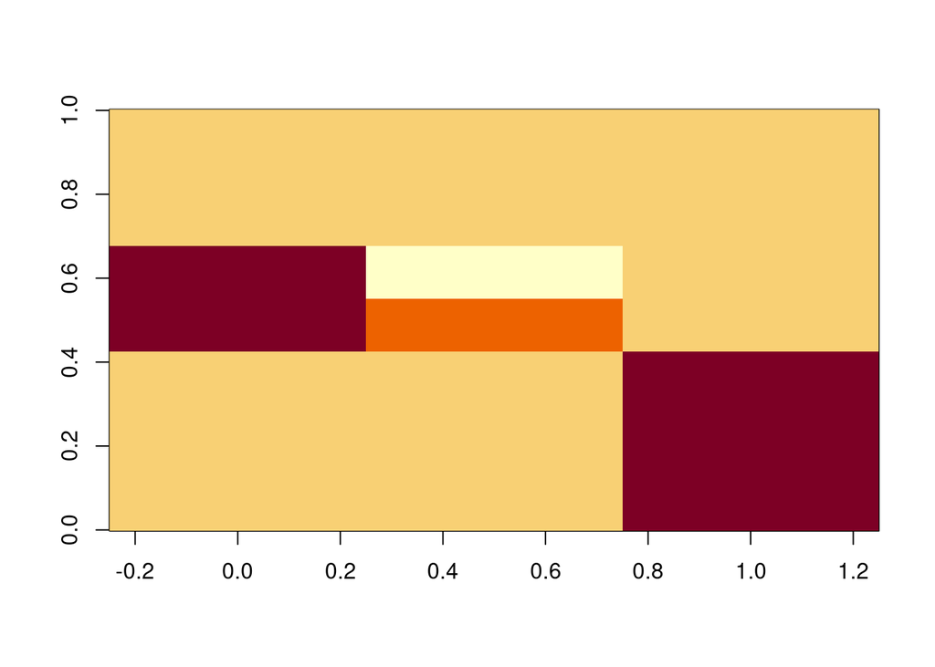

```r
# Only manipulation contrast
make_condition_contrast_image(X_e)
```

#### nWayAov

```r
# Get gMap
gMap <- get_gMap(X_e)
# Run nWayAOV
out <- get_bf_samp(y = dat$value, x = X_e, gMap = gMap, rscale = r,
                   no_iter = no_iter, filter_iter = filter_iter)
# Get simple BF
bf_out_e <- out[[1]]
# Get sampled data
samp_out_e <- out[[2]]
```

#### Check estimated values

```r
pm.effest.e <- colMeans(samp_out_e)
```

Contrasts:

- mu: payoff intercept
- beta 1: muller-lyer intercept
- beta 2: muller-lyer (pse-pmu)
- beta 3: base-rate intercept

```r
# get bias manipulation beta names
beta_names <- paste0('beta_', grep('x[0-9]{1}$', colnames(X_e)))

# Rename columns
sampled_means_e <-
  set_names(pm.effest.e[c('mu', beta_names)], c('mu', 'ml_int', 'ml_bd', 'br_int'))


# Sampled means
c(
  'ba' = dat %>% filter(bias_source == 'baserate') %>% reframe(value=mean(value)) %>% pull(),
  'pa' = dat %>% filter(bias_source == 'payoff') %>% reframe(value=mean(value)) %>% pull(),

  'mupse' = dat %>% filter(bias_source == 'mullerlyer', task == 'pse') %>% reframe(value=mean(value)) %>% pull(),
  'mupmu' = dat %>% filter(bias_source == 'mullerlyer', task == 'pmu') %>% reframe(value=mean(value)) %>% pull()
)
```

```
##        ba        pa     mupse     mupmu
## 10.923756 16.015405  7.783744 12.337037
```

```r
# Predicted means
c(
  'ba' = sampled_means_e['mu'] + sampled_means_e['br_int'],
  'pa' = sampled_means_e['mu'],
  'mupse' = sampled_means_e['mu'] + sampled_means_e['ml_int'] + contrast_value_pse * sampled_means_e['ml_bd'],
  'mupmu' = sampled_means_e['mu'] + sampled_means_e['ml_int'] + contrast_value_pmu * sampled_means_e['ml_bd']
)
```

```
##     ba.mu     pa.mu  mupse.mu  mupmu.mu
## 11.199137 15.211551  8.669685 12.454416
```

### Contrast F: No effect in any bias source [(mulo = mush) != (balo == bash) != (palo = pash)]

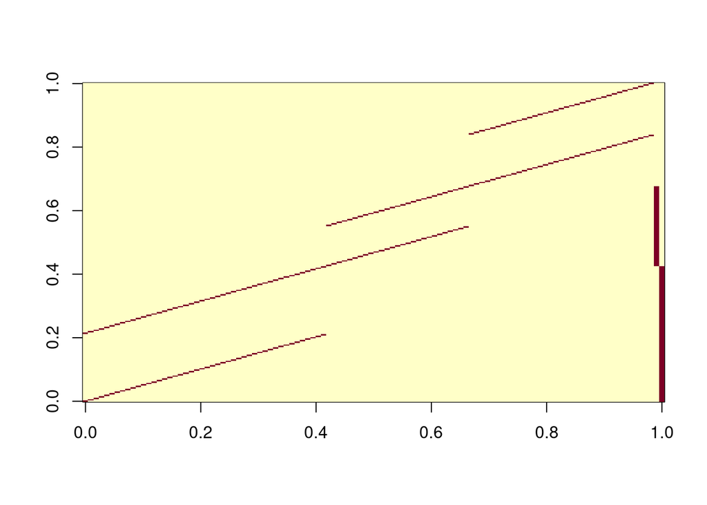

```r
# Get contrast
X_f <- get_contrast_F(dat)
# Full contrast image
image(t(X_f))
```

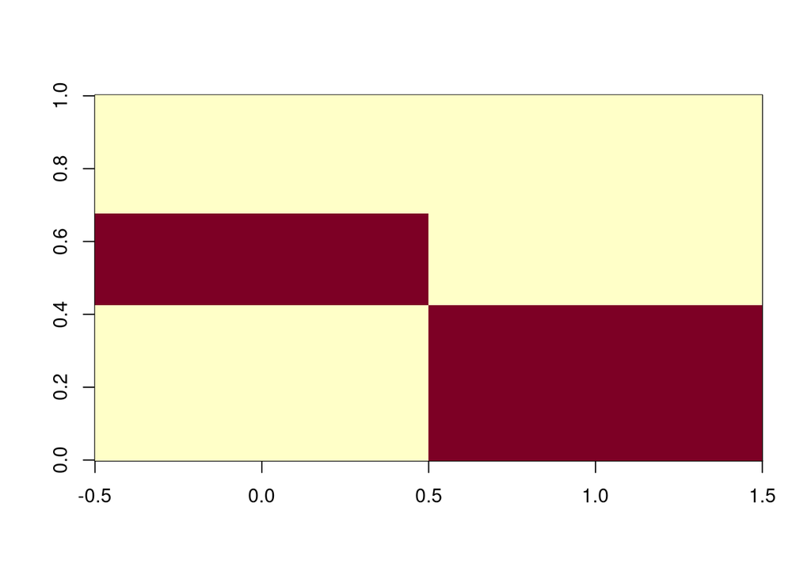

```r
# Only manipulation contrast
make_condition_contrast_image(X_f)
```

#### nWayAov

```r
# Get gMap
gMap <- get_gMap(X_f)
# Run nWayAOV
out <- get_bf_samp(y = dat$value, x = X_f, gMap = gMap, rscale = r,
                   no_iter = no_iter, filter_iter = filter_iter)
# Get simple BF
bf_out_f <- out[[1]]
# Get sampled data
samp_out_f <- out[[2]]
```

#### Check estimated values

Contrasts:

- mu: payoff intercept
- beta 1: muller-lyer intercept
- beta 2: base-rate intercept

```r
checkmeans_f <- with(dat, tapply(value, bias_source, mean))
pm.effest.f <- colMeans(samp_out_f)
```

```r
# get bias manipulation beta names
beta_names <- paste0('beta_', grep('x[0-9]{1}$', colnames(X_f)))

# Rename columns
sampled_means_f <-
  set_names(pm.effest.f[c('mu', beta_names)], c('mu', 'ml_int', 'br_int'))


# Compare means
checkmeans_f
```

```
##   baserate mullerlyer     payoff
##   10.92376   10.06039   16.01541
```

```r
c(
  'ba' = sampled_means_f['mu'] + sampled_means_f['br_int'],
  'ml' = sampled_means_f['mu'] + sampled_means_f['ml_int'],
  'pa' = sampled_means_f['mu']
)
```

```
##    ba.mu    ml.mu    pa.mu
## 11.19684 10.61418 15.27818
```

### Contrast G: Bias direction effect in base rate and Muller-Lyer, no effect in payoff [(mulo > mush) > (balo > bash) & (palo = pash)]

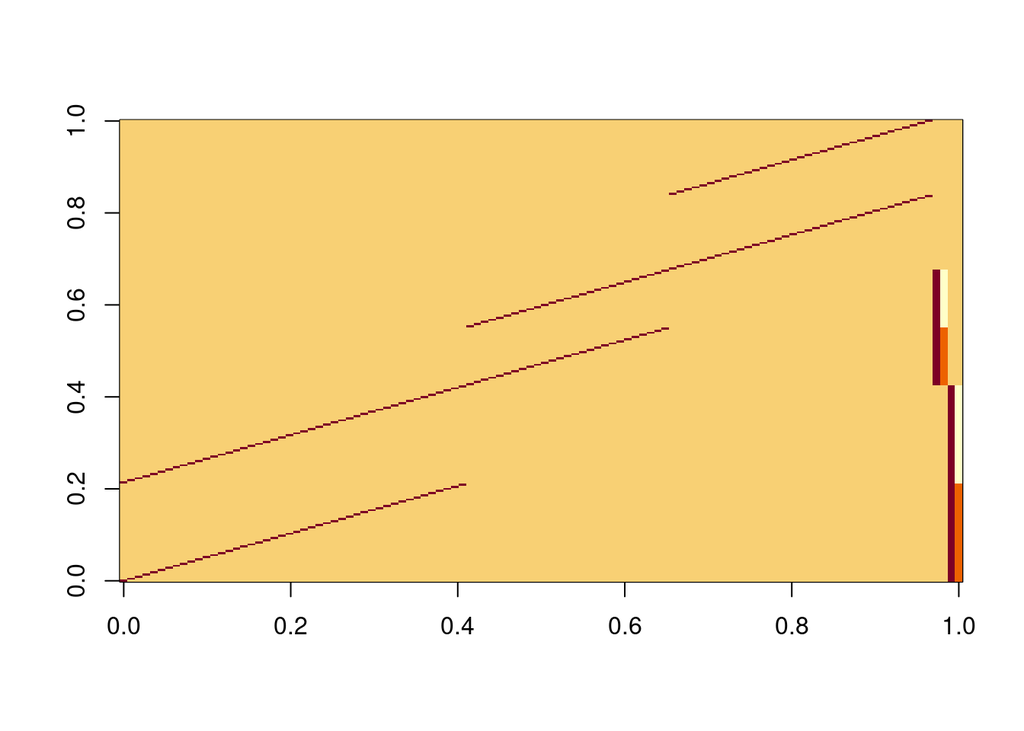

```r
# Get contrast
X_g <- get_contrast_G(dat, val_pse = contrast_value_pse, val_pmu = contrast_value_pmu)
# Full contrast image
image(t(X_g))
```

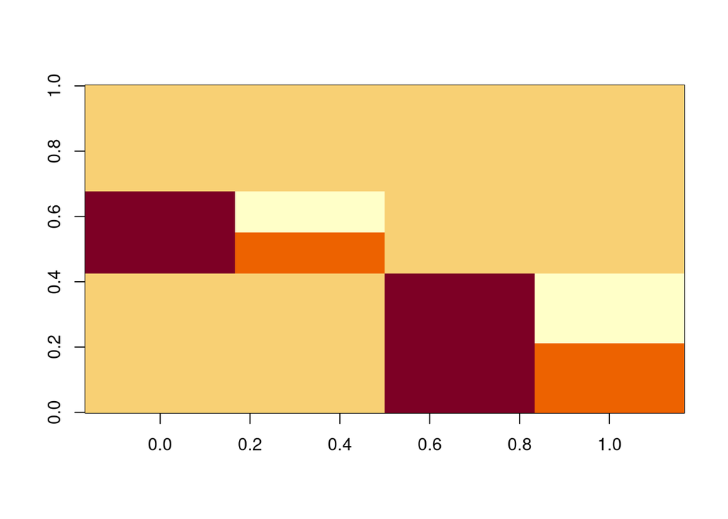

```r
# Only manipulation contrast
make_condition_contrast_image(X_g)
```

#### nWayAov

```r
# Get gMap
gMap <- get_gMap(X_g)
# Run nWayAOV
out <- get_bf_samp(y = dat$value, x = X_g, gMap = gMap, rscale = r,
                   no_iter = no_iter, filter_iter = filter_iter)
# Get simple BF
bf_out_g <- out[[1]]
# Get sampled data
samp_out_g <- out[[2]]
```

#### Check estimated values

```r
pm.effest.g <- colMeans(samp_out_g)
```

Contrasts:

- mu: payoff intercept
- beta 1: muller-lyer intercept
- beta 2: muller-lyer (pse-pmu)
- beta 3: base-rate intercept
- beta 4: base-rate (pse-pmu)

```r
# get bias manipulation beta names
beta_names <- paste0('beta_', grep('x[0-9]{1}$', colnames(X_g)))

# Rename columns
sampled_means_g <-
  set_names(pm.effest.g[c('mu', beta_names)], c('mu', 'ml_int', 'ml_bd', 'br_int', 'br_bd'))
```

```r
c(
  checkmeans_a[c('bapse','bapmu', 'mupse', 'mupmu')],
  'pa' = dat %>% filter(bias_source == 'payoff') %>% reframe(value=mean(value)) %>% pull()
)
```

```
##     bapse     bapmu     mupse     mupmu        pa
## 14.517078  7.330435  7.783744 12.337037 16.015405
```

```r
c(
  'bapse' = sampled_means_g['mu'] + sampled_means_g['br_int'] - .5 * sampled_means_g['br_bd'],
  'bapmu' = sampled_means_g['mu'] + sampled_means_g['br_int'] + .5 * sampled_means_g['br_bd'],

  'mupse' = sampled_means_g['mu'] + sampled_means_g['ml_int'] - .5 * sampled_means_g['ml_bd'],
  'mupse' = sampled_means_g['mu'] + sampled_means_g['ml_int'] + .5 * sampled_means_g['ml_bd'],

  'pa' = sampled_means_g['mu']
)
```

```
##  bapse.mu  bapmu.mu  mupse.mu  mupse.mu     pa.mu
## 14.522707  7.906304  8.674963 12.506251 15.246062
```

### Contrast H: Bias direction effect in Payoff and Muller-Lyer, no effect in base rate [(mulo > mush) > (palo > pash) & (balo = bash)]

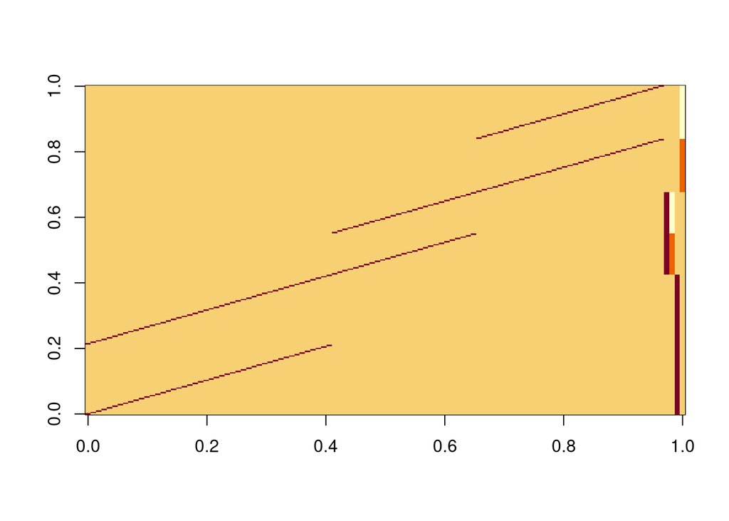

```r
# Get contrast
X_h <- get_contrast_H(dat, val_pse = contrast_value_pse, val_pmu = contrast_value_pmu)
# Full contrast image
image(t(X_h))
```

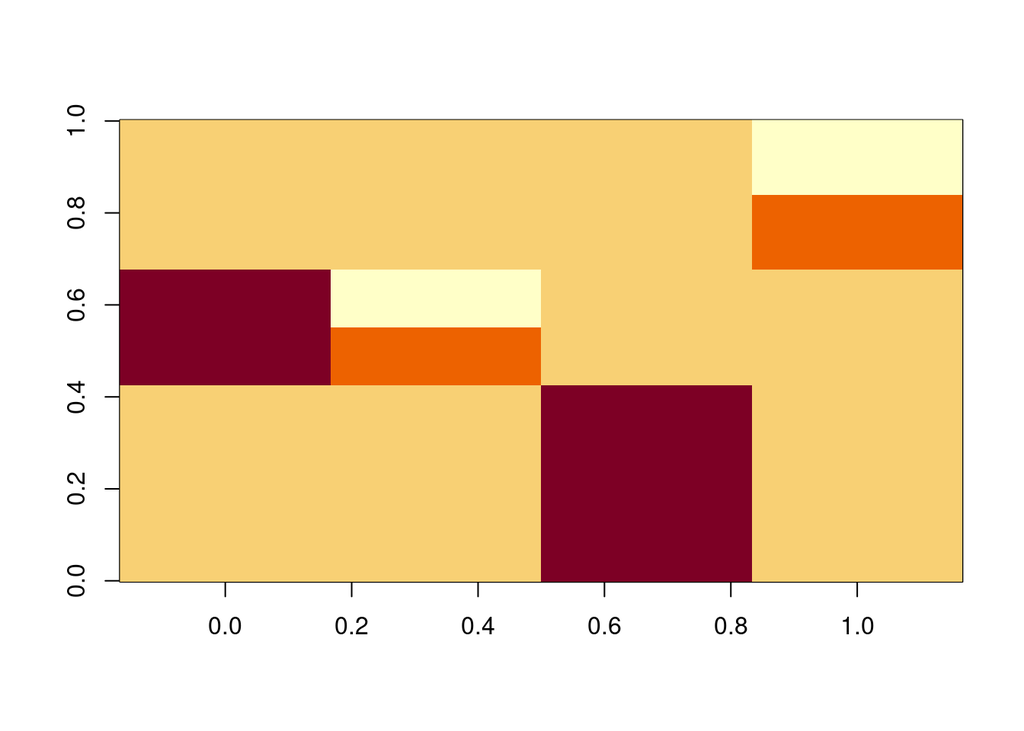

```r
# Only manipulation contrast
make_condition_contrast_image(X_h)
```

#### nWayAov

```r
# Get gMap
gMap <- get_gMap(X_h)
# Run nWayAOV
out <- get_bf_samp(y = dat$value, x = X_h, gMap = gMap, rscale = r,
                   no_iter = no_iter, filter_iter = filter_iter)
# Get simple BF
bf_out_h <- out[[1]]
# Get sampled data
samp_out_h <- out[[2]]
```

#### Check estimated values

```r
pm.effest.h <- colMeans(samp_out_h)
```

Contrasts:

```r
# get bias manipulation beta names
beta_names <- paste0('beta_', grep('x[0-9]{1}$', colnames(X_h)))

# Rename columns
sampled_means_h <-
  set_names(pm.effest.h[c('mu', beta_names)], c('mu', 'ml_int', 'ml_bd', 'br_int', 'po_bd'))
```

```r
c(
  checkmeans_a[c('papse', 'papmu', 'mupse', 'mupmu')],
  'ba' = dat %>% filter(bias_source == 'baserate') %>% reframe(value=mean(value)) %>% pull()
)
```

```
##     papse     papmu     mupse     mupmu        ba
## 21.367954 10.662857  7.783744 12.337037 10.923756
```

```r
c(

  'papse' = sampled_means_h['mu'] - .5 * sampled_means_h['po_bd'],
  'papmu' = sampled_means_h['mu'] + .5 * sampled_means_h['po_bd'],

  'mupse' = sampled_means_h['mu'] + sampled_means_h['ml_int'] - .5 * sampled_means_h['ml_bd'],
  'mupmu' = sampled_means_h['mu'] + sampled_means_h['ml_int'] + .5 * sampled_means_h['ml_bd'],

  'ba' = sampled_means_h['mu'] + sampled_means_h['br_int']

)
```

```
##  papse.mu  papmu.mu  mupse.mu  mupmu.mu     ba.mu
## 20.070243 10.258616  8.726368 12.534882 11.189755
```

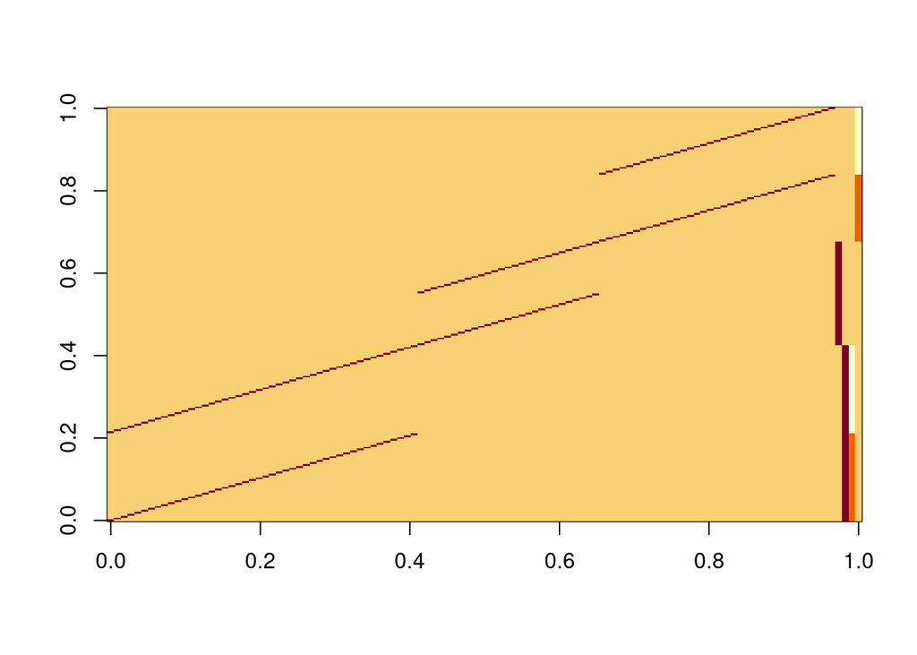

```r
# Get contrast
X_i <- get_contrast_I(dat, val_pse = contrast_value_pse, val_pmu = contrast_value_pmu)
# Full contrast image
image(t(X_i))
```

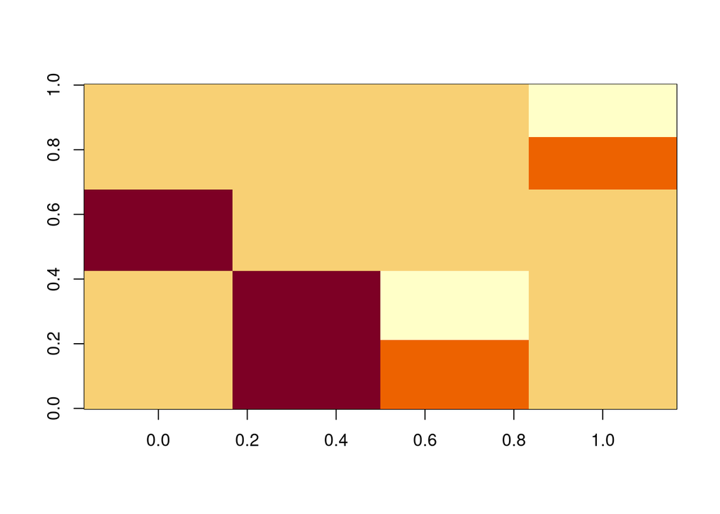

```r
# Only manipulation contrast
make_condition_contrast_image(X_i)
```

#### nWayAov

```r
# Get gMap
gMap <- get_gMap(X_i)
# Run nWayAOV
out <- get_bf_samp(y = dat$value, x = X_i, gMap = gMap, rscale = r,
                   no_iter = no_iter, filter_iter = filter_iter)
# Get simple BF
bf_out_i <- out[[1]]
# Get sampled data
samp_out_i <- out[[2]]
```

#### Check estimated values

```r
pm.effest.i <- colMeans(samp_out_i)
```

Contrasts:

- mu: payoff intercept
- beta 1: muller-lyer intercept
- beta 2: base-rate intercept
- beta 3: base-rate (pse-pmu)
- beta 4: payoff (pse-pmu)

```r
# get bias manipulation beta names
beta_names <- paste0('beta_', grep('x[0-9]{1}$', colnames(X_i)))

# Rename columns
sampled_means_i <-
  set_names(pm.effest.i[c('mu', beta_names)], c('mu', 'ml_int', 'br_int', 'br_bd', 'po_bd'))
```

```r
c(mu = mean(checkmeans_a[c('mupse', 'mupmu')]), checkmeans_a[c('papse', 'papmu', 'bapse', 'bapmu')])
```

```
##        mu     papse     papmu     bapse     bapmu
## 10.060391 21.367954 10.662857 14.517078  7.330435
```

```r
c(
  'mu' = sampled_means_i['mu'] + sampled_means_i['ml_int'],

  'papse' = sampled_means_i['mu'] - .5 * sampled_means_i['po_bd'],
  'papmu' = sampled_means_i['mu'] + .5 * sampled_means_i['po_bd'],

  'bapse' = sampled_means_i['mu'] + sampled_means_i['br_int'] - .5 * sampled_means_i['br_bd'],
  'bapmu' = sampled_means_i['mu'] + sampled_means_i['br_int'] + .5 * sampled_means_i['br_bd']

)
```

```
##     mu.mu  papse.mu  papmu.mu  bapse.mu  bapmu.mu
## 10.612164 20.146547 10.122468 14.573878  7.951859
```

### Contrast J: Bias direction effect in the payoff condition, no effect in base rate and muller lyer [(palo > pash) & (balo == bash) & (mulo = mush)]

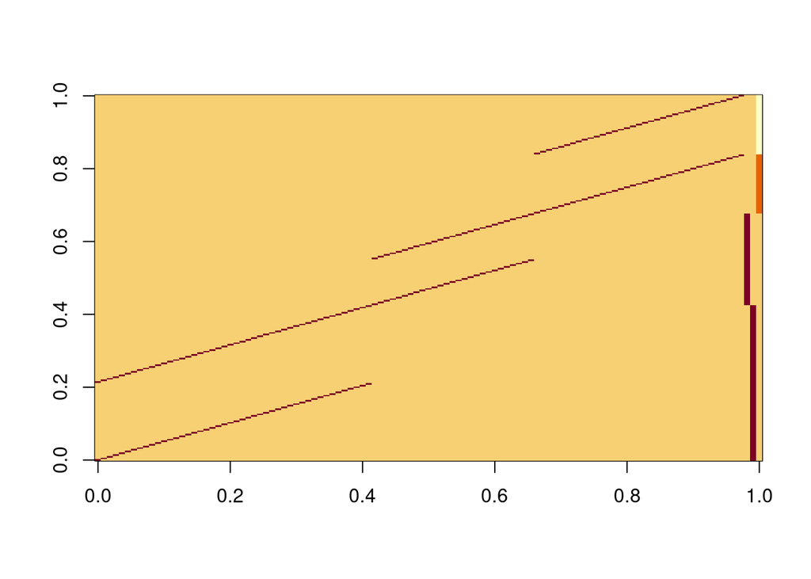

```r
# Get contrast
X_j <- get_contrast_J(dat, val_pse = contrast_value_pse, val_pmu = contrast_value_pmu)
# Full contrast image
image(t(X_j))
```

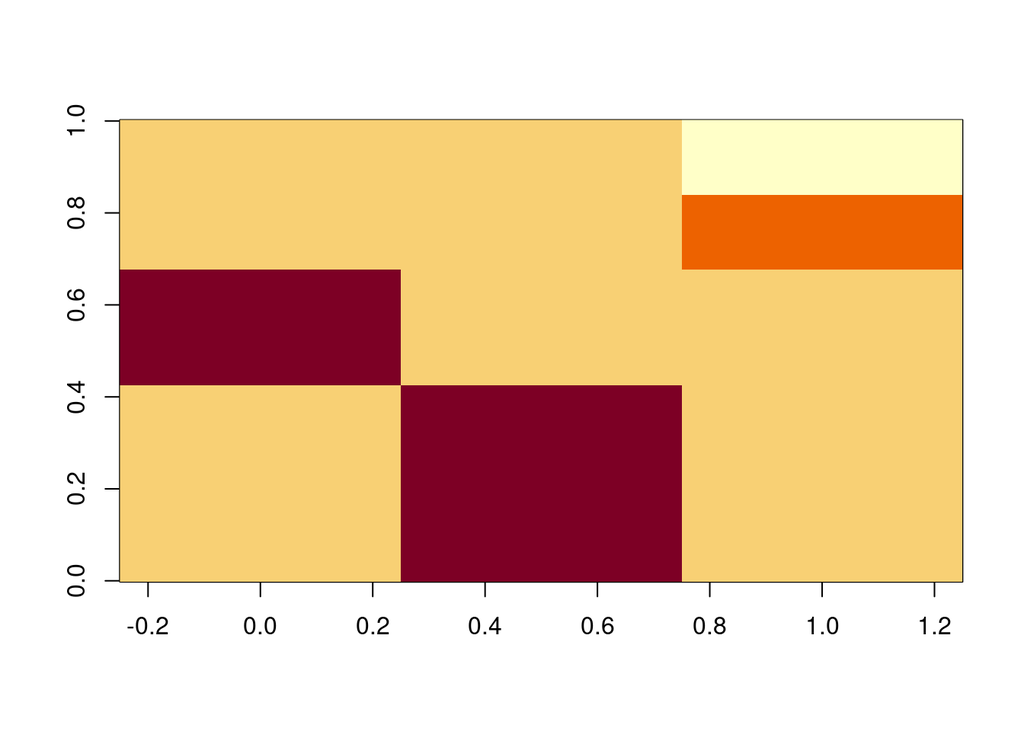

```r
# Only manipulation contrast
make_condition_contrast_image(X_j)
```

#### nWayAov

```r
# Get gMap
gMap <- get_gMap(X_j)
# Run nWayAOV
out <- get_bf_samp(y = dat$value, x = X_j, gMap = gMap, rscale = r,
                   no_iter = no_iter, filter_iter = filter_iter)
# Get simple BF
bf_out_j <- out[[1]]
# Get sampled data
samp_out_j <- out[[2]]
```

#### Check estimated values

```r
pm.effest.j <- colMeans(samp_out_j)
```

Contrasts:

- mu: payoff intercept
- beta 1: muller-lyer intercept
- beta 2: base-rate intercept
- beta 3: payoff (pse-pmu)

```r
# get bias manipulation beta names
beta_names <- paste0('beta_', grep('x[0-9]{1}$', colnames(X_j)))

# Rename columns
sampled_means_j <-
  set_names(pm.effest.j[c('mu', beta_names)], c('mu', 'ml_int', 'br_int', 'pa_bd'))
```

```r
c(
  'ba' = dat %>% filter(bias_source == 'baserate') %>% reframe(value=mean(value)) %>% pull(),
  'pa' = dat %>% filter(bias_source == 'payoff') %>% reframe(value=mean(value)) %>% pull(),
  checkmeans_a['papse'],
  checkmeans_a['papmu']
)
```

```
##       ba       pa    papse    papmu
## 10.92376 16.01541 21.36795 10.66286
```

```r
c(

  'ba' = sampled_means_j['mu'] + sampled_means_j['br_int'],
  'mu' = sampled_means_j['mu'] + sampled_means_j['ml_int'],

  'papse' = sampled_means_j['mu'] - .5 * sampled_means_j['pa_bd'],
  'papmu' = sampled_means_j['mu'] + .5 * sampled_means_j['pa_bd']


)
```

```
##    ba.mu    mu.mu papse.mu papmu.mu
## 11.25534 10.63849 20.09239 10.28803
```

### Contrast K: Bias direction effect in the base-rate condition, no effect in payoff and muller lyer [(balo > bash) & (palo == pash) & (mulo = mush)]

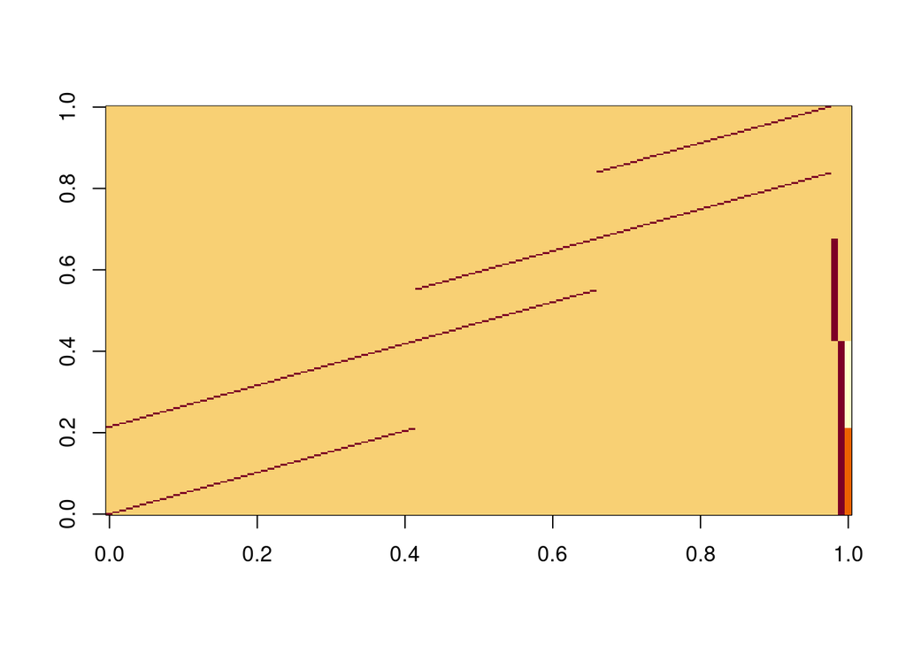

```r
# Get contrast
X_k <- get_contrast_K(dat, val_pse = contrast_value_pse, val_pmu = contrast_value_pmu)
# Full contrast image
image(t(X_k))
```

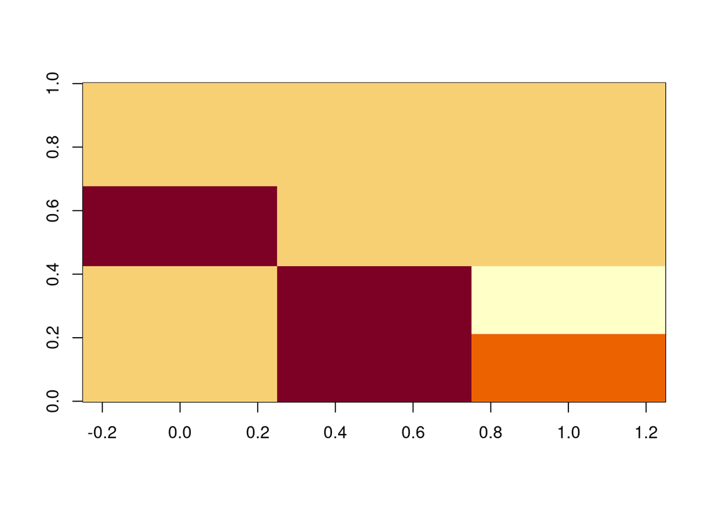

```r
# Only manipulation contrast
make_condition_contrast_image(X_k)
```

#### nWayAov

```r
# Get gMap
gMap <- get_gMap(X_k)
# Run nWayAOV
out <- get_bf_samp(y = dat$value, x = X_k, gMap = gMap, rscale = r,
                   no_iter = no_iter, filter_iter = filter_iter)
# Get simple BF
bf_out_k <- out[[1]]
# Get sampled data
samp_out_k <- out[[2]]
```

#### Check estimated values

```r
pm.effest.k <- colMeans(samp_out_k)
```

Contrasts:

```r
# get bias manipulation beta names
beta_names <- paste0('beta_', grep('x[0-9]{1}$', colnames(X_k)))

# Rename columns
sampled_means_k <-
  set_names(pm.effest.k[c('mu', beta_names)], c('mu', 'ml_int', 'br_int', 'ba_bd'))

c(
  'bapse' = checkmeans_a['bapse'],
  'bapmu' = checkmeans_a['bapmu'],
  'mu' = dat %>% filter(bias_source == 'mullerlyer') %>% reframe(value=mean(value)) %>% pull(),
  'pa' = dat %>% filter(bias_source == 'payoff') %>% reframe(value=mean(value)) %>% pull()
)
```

```
## bapse.bapse bapmu.bapmu          mu          pa
##   14.517078    7.330435   10.060391   16.015405
```

```r
c(

  'bapse' = sampled_means_k['mu'] + sampled_means_k['br_int'] - .5 * sampled_means_k['ba_bd'],
  'bapmu' = sampled_means_k['mu'] + sampled_means_k['br_int'] + .5 * sampled_means_k['ba_bd'],
  'mu' = sampled_means_k['mu'] + sampled_means_k['ml_int'],
  'papse' = sampled_means_k['mu']

)
```

```
##  bapse.mu  bapmu.mu     mu.mu  papse.mu
## 14.551973  7.924865 10.588858 15.263611
```

## Priors

```r
# Parameters for prior sampling
R <- 1000000
mu.theta.sd <- 1
# Prior sample
ml <- rnorm(R, 0, mu.theta.sd)
br <- rnorm(R, 0, mu.theta.sd)
po <- rnorm(R, 0, mu.theta.sd)
```

## Posteriors

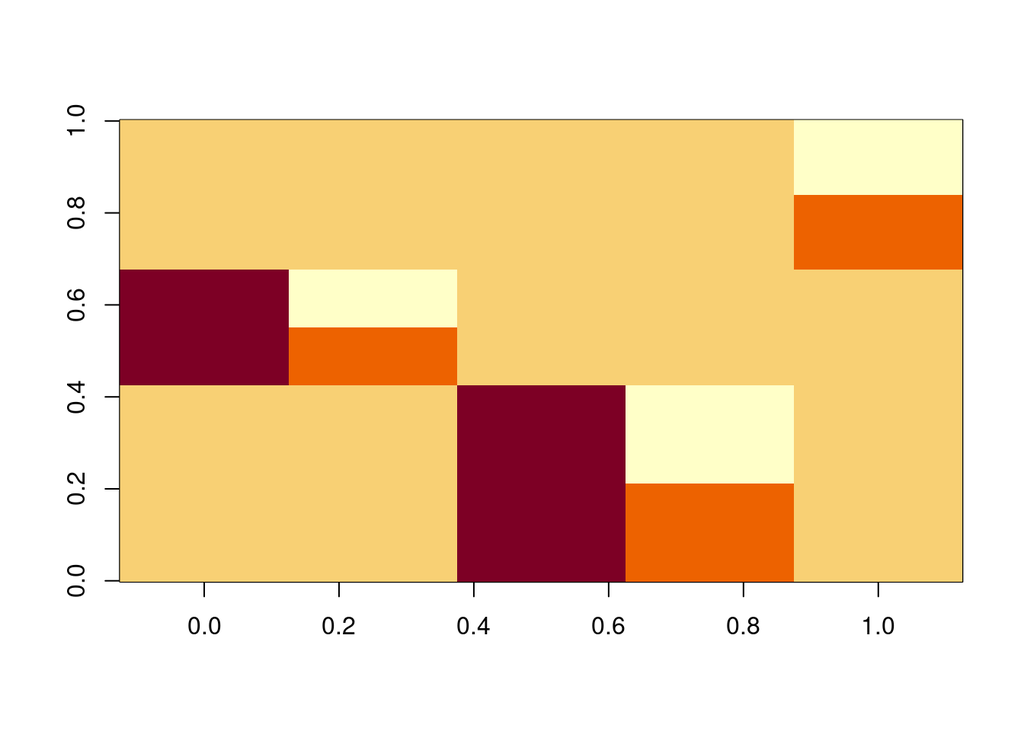

```r
# Number of participant contrast columns
add_to_beta_index <- ncol(id_contrast)

### CONTRAST A -----------------------------------------------------------------

priorA <- mean(ml > 0 & br > 0 & po > 0)

# There is an effect in all conditions
make_condition_contrast_image(X_a)
```

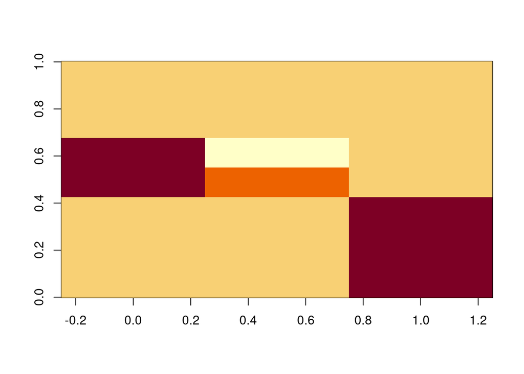

```r
# Column names of beta columns of bias direction effects
ml_bd <- paste0('beta_', 2 + add_to_beta_index)
br_bd <- paste0('beta_', 4 + add_to_beta_index)
po_bd <- paste0('beta_', 5 + add_to_beta_index)

ml_effect <- samp_out_a[, ml_bd]
br_effect <- samp_out_a[, br_bd]
po_effect <- samp_out_a[, po_bd]

ml_pos <- ml_effect > 0
ml_neg <- ml_effect < 0
br_pos <- br_effect > 0
br_neg <- br_effect < 0
po_pos <- po_effect > 0
po_neg <- po_effect < 0

# dec > conf in all conditions
postAA <- mean(ml_pos & br_pos & po_pos)
# dec > conf in ml/br, dec < conf in po
postAB <- mean(ml_pos & br_pos & po_neg)
# dec > conf in ml/po & dec < conf in br
postAC <- mean(ml_pos & br_neg & po_pos)
# dec > conf in ml & dec < conf in br/po
postAD <- mean(ml_pos & br_neg & po_neg)
# dec > conf in br/po & dec < conf in ml
postAE <- mean(ml_neg & br_pos & po_pos)
# dec > conf in br & dec < conf in ml/po
postAF <- mean(ml_neg & br_pos & po_neg)
# dec > conf in po & dec < conf in ml/br
postAG <- mean(ml_neg & br_neg & po_pos)
#dec < conf in all condition
postAH <- mean(ml_neg & br_neg & po_neg)

### CONTRAST E -----------------------------------------------------------------

priorE <- mean(ml > 0)

# There is an effect in all conditions
make_condition_contrast_image(X_e)
```

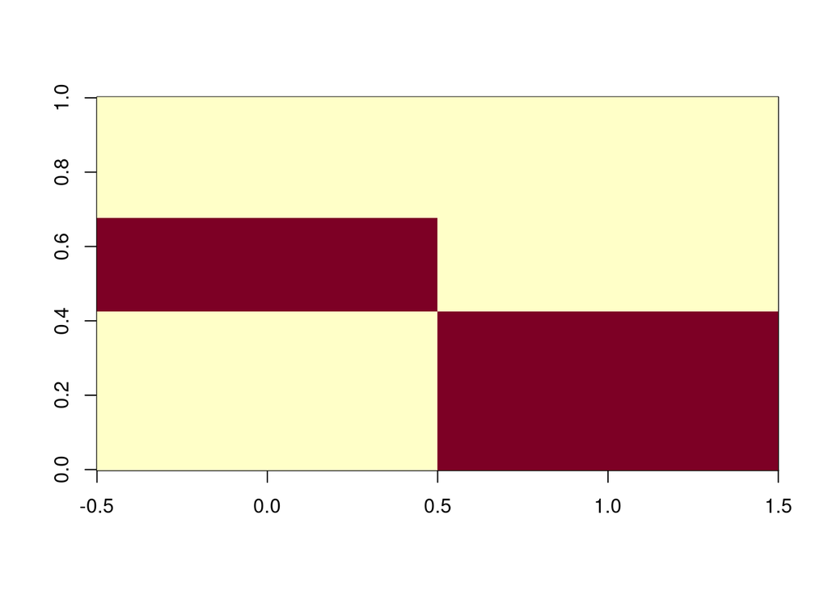

```r
# Column names of beta columns of bias direction effects
ml_bd <- paste0('beta_', 2 + add_to_beta_index)

ml_effect <- samp_out_e[, ml_bd]

ml_pos <- ml_effect > 0
ml_neg <- ml_effect < 0

# dec > conf
postEA <- mean(ml_pos)
# dec < conf
postEB <- mean(ml_neg)

### CONTRAST F -----------------------------------------------------------------

# There is an effect in all conditions
make_condition_contrast_image(X_f)
```

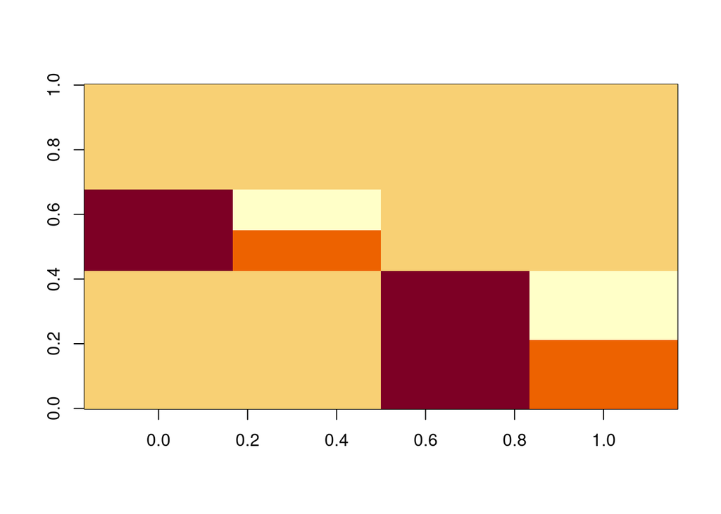

```r
### CONTRAST G -----------------------------------------------------------------

priorG <- mean(ml > 0 & br > 0)

# There is an effect in all conditions
make_condition_contrast_image(X_g)
```

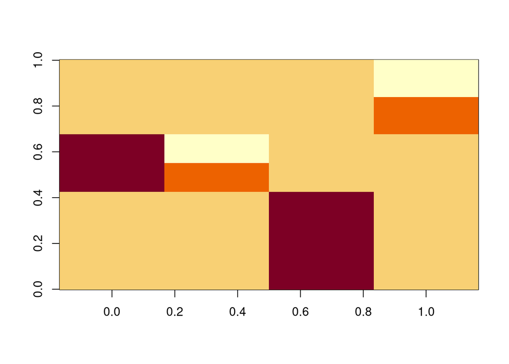

```r
# Column names of beta columns of bias direction effects
ml_bd <- paste0('beta_', 2 + add_to_beta_index)
br_bd <- paste0('beta_', 4 + add_to_beta_index)

ml_effect <- samp_out_g[, ml_bd]
br_effect <- samp_out_g[, br_bd]

ml_pos <- ml_effect > 0
ml_neg <- ml_effect < 0
br_pos <- br_effect > 0
br_neg <- br_effect < 0

# dec > conf in all conditions
postGA <- mean(ml_pos & br_pos)
# dec > conf in ml/po & dec < conf in br
postGB <- mean(ml_pos & br_neg)
# dec > conf in br/po & dec < conf in ml
postGC <- mean(ml_neg & br_pos)
# dec > conf in po & dec < conf in ml/br
postGD <- mean(ml_neg & br_neg)

### CONTRAST H -----------------------------------------------------------------

priorH <- mean(ml > 0 & po > 0)

# There is an effect in all conditions
make_condition_contrast_image(X_h)
```

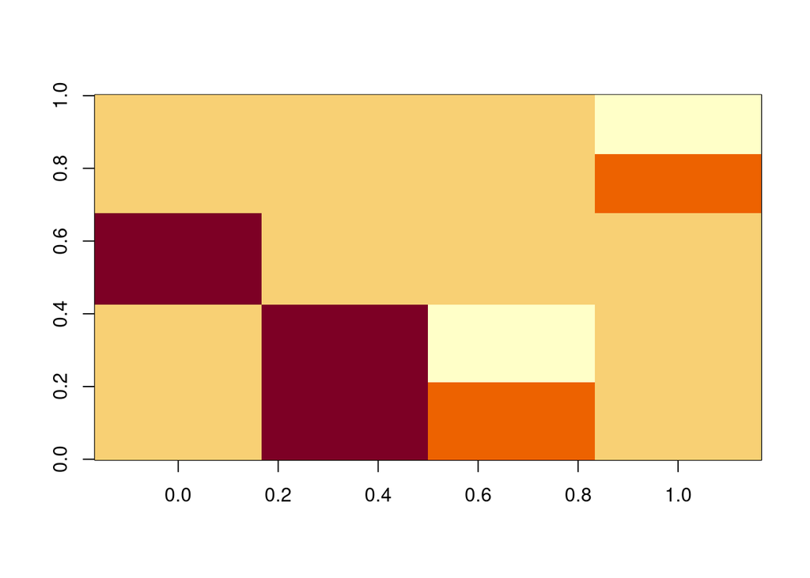

```r
# Column names of beta columns of bias direction effects
ml_bd <- paste0('beta_', 2 + add_to_beta_index)
po_bd <- paste0('beta_', 4 + add_to_beta_index)

ml_effect <- samp_out_h[, ml_bd]
po_effect <- samp_out_h[, po_bd]

ml_pos <- ml_effect > 0
ml_neg <- ml_effect < 0
po_pos <- po_effect > 0
po_neg <- po_effect < 0

# dec > conf in all conditions
postHA <- mean(ml_pos & po_pos)
# dec > conf in ml/po & dec < conf in br
postHB <- mean(ml_pos & po_neg)
# dec > conf in br/po & dec < conf in ml
postHC <- mean(ml_neg & po_pos)
# dec > conf in po & dec < conf in ml/br
postHD <- mean(ml_neg & po_neg)

### CONTRAST I -----------------------------------------------------------------

priorI <- mean(br > 0 & po > 0)

# There is an effect in all conditions
make_condition_contrast_image(X_i)
```

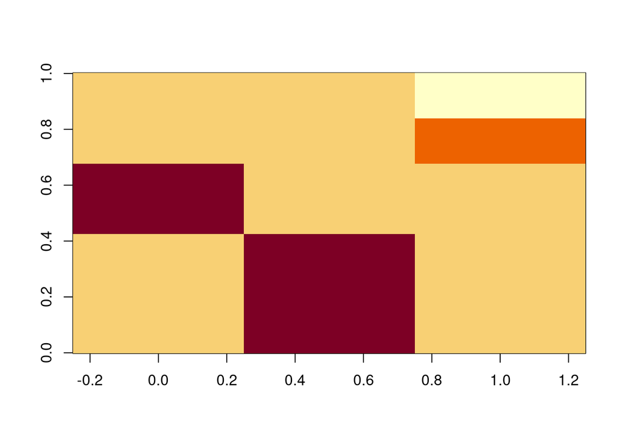

```r
# Column names of beta columns of bias direction effects
br_bd <- paste0('beta_', 3 + add_to_beta_index)
po_bd <- paste0('beta_', 4 + add_to_beta_index)

br_effect <- samp_out_i[, ml_bd]
po_effect <- samp_out_i[, po_bd]

br_pos <- br_effect > 0
br_neg <- br_effect < 0
po_pos <- po_effect > 0
po_neg <- po_effect < 0

# dec > conf in all conditions
postIA <- mean(br_pos & po_pos)
# dec > conf in br/po & dec < conf in br
postIB <- mean(br_pos & po_neg)
# dec > conf in br/po & dec < conf in br
postIC <- mean(br_neg & po_pos)
# dec > conf in po & dec < conf in br/br
postID <- mean(br_neg & po_neg)


### CONTRAST J -----------------------------------------------------------------

priorJ <- mean(po > 0)

# There is an effect in all conditions
make_condition_contrast_image(X_j)
```

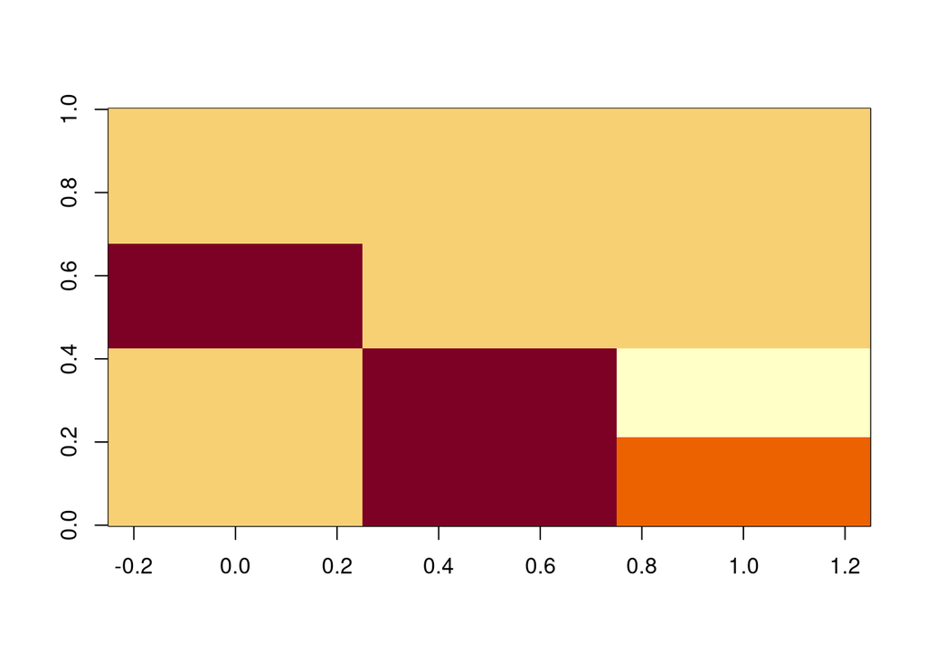

```r
# Column names of beta columns of bias direction effects
po_bd <- paste0('beta_', 3 + add_to_beta_index)

po_effect <- samp_out_j[, po_bd]

po_pos <- po_effect > 0
po_neg <- po_effect < 0

# dec > conf
postJA <- mean(po_pos)
# dec < conf
postJB <- mean(po_neg)

### CONTRAST K -----------------------------------------------------------------

priorK <- mean(br > 0)

# There is an effect in all conditions
make_condition_contrast_image(X_k)
```

```r
# Column names of beta columns of bias direction effects
br_bd <- paste0('beta_', 3 + add_to_beta_index)

br_effect <- samp_out_k[, br_bd]

br_brs <- br_effect > 0
br_neg <- br_effect < 0

# dec > conf
postKA <- mean(br_brs)
# dec < conf
postKB <- mean(br_neg)
```

### Calculate ordinal BF

```r
# Unconstrained model
bf_uN <- bf_out_f$bf

# # model A: effect on all conditions, no constrained across them
# bf_A <- bf_out_a$bf
# # model B: effect only in Payoff
# bf_B <- bf_out_j$bf
# # model C: effect only in Muller-Lyer
# bf_C <- bf_out_e$bf
# # model D: effect only in Base rate
# bf_D <- bf_out_k$bf
# # model E: effect in Payoff and Baserate, no effect in Muller-Lyer
# bf_E <- bf_out_i$bf
# # model F: effect in Payoff and Muller-Lyer, no effect in Baserate
# bf_F <- bf_out_h$bf
# # model G: effect in Muller-Lyer and Baserate, no effect in Payoff
# bf_G <- bf_out_g$bf

# More-constrained models ---------------------------------

# model AA
bf_AA <- log(postAA / priorA) + bf_out_a$bf
# model AB
bf_AB <- log(postAB / priorA) + bf_out_a$bf
# model AC
bf_AC <- log(postAC / priorA) + bf_out_a$bf
# model AD
bf_AD <- log(postAD / priorA) + bf_out_a$bf
# model AE
bf_AE <- log(postAE / priorA) + bf_out_a$bf
# model AF
bf_AF <- log(postAF / priorA) + bf_out_a$bf
# model AG
bf_AG <- log(postAG / priorA) + bf_out_a$bf
# model AH
bf_AH <- log(postAH / priorA) + bf_out_a$bf

# model EA
bf_EA <- log(postEA / priorE) + bf_out_e$bf
# model EB
bf_EB <- log(postEB / priorE) + bf_out_e$bf

# model GA
bf_GA <- log(postGA / priorG) + bf_out_g$bf
# model GB
bf_GB <- log(postGB / priorG) + bf_out_g$bf
# model GC
bf_GC <- log(postGC / priorG) + bf_out_g$bf
# model GD
bf_GD <- log(postGD / priorG) + bf_out_g$bf

# model HA
bf_HA <- log(postHA / priorH) + bf_out_h$bf
# model HB
bf_HB <- log(postHB / priorH) + bf_out_h$bf
# model HC
bf_HC <- log(postHC / priorH) + bf_out_h$bf
# model HD
bf_HD <- log(postHD / priorH) + bf_out_h$bf

# model IA
bf_IA <- log(postIA / priorI) + bf_out_i$bf
# model IB
bf_IB <- log(postIB / priorI) + bf_out_i$bf
# model IC
bf_IC <- log(postIC / priorI) + bf_out_i$bf
# model ID
bf_ID <- log(postID / priorI) + bf_out_i$bf

# model JA
bf_JA <- log(postJA / priorJ) + bf_out_j$bf
# model JB
bf_JB <- log(postJB / priorJ) + bf_out_j$bf

# model KA
bf_KA <- log(postKA / priorK) + bf_out_k$bf
# model KB
bf_KB <- log(postKB / priorK) + bf_out_k$bf
```

## Make table with bf values

```r
bfs <-
  tribble(
    ~model, ~bf, ~model_label,
    # 'a', bf_A, 'BR&ML&PO',
    # 'b', bf_B, 'PO',
    # 'c', bf_C, 'ML',
    # 'd', bf_D, 'BR',
    # 'e', bf_E, 'BR & PO',
    # 'f', bf_F, 'ML & PO',
    # 'g', bf_G, 'BR & ML',
    # data-driven models
    'AA', bf_AA, 'ml+ & br+ & po+',
    'AB', bf_AB, 'ml+ & br+ & po-',
    'AC', bf_AC, 'ml+ & br- & po+',
    'AD', bf_AD, 'ml+ & br- & po-',
    'AE', bf_AE, 'ml- & br+ & po+',
    'AF', bf_AF, 'ml- & br+ & po-',
    'AG', bf_AG, 'ml- & br- & po+',
    'AH', bf_AH, 'ml- & br- & po-',

    'EA', bf_EA, 'ml+ & br= & po=',
    'EB', bf_EB, 'ml- & br= & po=',

    'GA', bf_GA, 'ml+ & br+ & po=',
    'GB', bf_GB, 'ml+ & br- & po=',
    'GC', bf_GC, 'ml- & br+ & po=',
    'GD', bf_GD, 'ml- & br- & po=',

    'HA', bf_HA, 'ml+ & br= & po+',
    'HB', bf_HB, 'ml+ & br= & po-',
    'HC', bf_HC, 'ml- & br= & po+',
    'HD', bf_HD, 'ml- & br= & po-',

    'IA', bf_IA, 'ml= & br+ & po+',
    'IB', bf_IB, 'ml= & br+ & po-',
    'IC', bf_IC, 'ml= & br- & po+',
    'ID', bf_ID, 'ml= & br- & po-',

    'JA', bf_JA, 'ml= & br= & po+',
    'JB', bf_JB, 'ml= & br= & po-',

    'KA', bf_KA, 'ml= & br+ & po=',
    'KB', bf_KB, 'ml= & br- & po=',

    'UN', bf_uN, 'BR & ML & PO (no effect in all manipulations)'
  )

bfs %>%
  write_csv(here(sprintf('data/ordinal_modeling/ord_models_conf-dec_%s.csv', exp_data)))
```

```r
bfs_based <- bfs %>%
  mutate(baseline = bfs %>% filter(model == 'UN') %>% pull(bf),
         bf_over_baseline = bf-baseline) %>%
  arrange(desc(bf_over_baseline)) %>%
  filter(bf_over_baseline > 0)

bfs_based
```

```
## # A tibble: 14 × 5
##    model    bf model_label     baseline bf_over_baseline
##    <chr> <dbl> <chr>              <dbl>            <dbl>
##  1 AD    18.0  ml+ & br- & po-     7.44           10.6
##  2 ID    17.6  ml= & br- & po-     7.44           10.1
##  3 AH    15.5  ml- & br- & po-     7.44            8.06
##  4 IB    14.9  ml= & br+ & po-     7.44            7.44
##  5 HB    14.1  ml+ & br= & po-     7.44            6.70
##  6 JB    13.7  ml= & br= & po-     7.44            6.30
##  7 HD    11.7  ml- & br= & po-     7.44            4.22
##  8 AB    11.7  ml+ & br+ & po-     7.44            4.21
##  9 GB    10.9  ml+ & br- & po=     7.44            3.48
## 10 KB    10.6  ml= & br- & po=     7.44            3.20
## 11 AF    10.4  ml- & br+ & po-     7.44            2.96
## 12 IC     9.22 ml= & br- & po+     7.44            1.78
## 13 GD     8.52 ml- & br- & po=     7.44            1.08
## 14 EA     7.59 ml+ & br= & po=     7.44            0.151
```

```r
bfs_based %>%
  mutate(bf_over_rest = exp(max(bf_over_baseline) - bf_over_baseline)) %>% filter(bf_over_rest < 100)
```

```
## # A tibble: 6 × 6
##   model    bf model_label     baseline bf_over_baseline bf_over_rest
##   <chr> <dbl> <chr>              <dbl>            <dbl>        <dbl>
## 1 AD     18.0 ml+ & br- & po-     7.44            10.6          1
## 2 ID     17.6 ml= & br- & po-     7.44            10.1          1.61
## 3 AH     15.5 ml- & br- & po-     7.44             8.06        12.7
## 4 IB     14.9 ml= & br+ & po-     7.44             7.44        23.7
## 5 HB     14.1 ml+ & br= & po-     7.44             6.70        49.2
## 6 JB     13.7 ml= & br= & po-     7.44             6.30        73.4
```